# Mortgage Payment and Default

# 1 Descriptive Statistics

## 1.1 30% Negative Equity Loans

```
##
## =====================================================================
## Statistic        Mean      St. Dev.  Pctl(25) Median  Pctl(75)   N
## ---------------------------------------------------------------------
## def              0.058      0.233       0        0       0     21,692
## mpay_value       0.009      0.001     0.008    0.009   0.009   21,692
## rent_value       0.009      0.002     0.008    0.009   0.010   21,692
## fico            720.057     54.094     681      723     765    21,681
## ltv             81.035      8.528       77      80       88    21,692
## dti             38.398      11.331      30      38       46    21,170
## upb           212,090.200 79,135.740 154,000  200,000 262,000  21,692
## interestrate     6.229      0.433     5.875    6.250   6.500   21,692
## interest_diff    0.039      0.354     -0.178   0.030   0.238   21,692
## org_year       2,006.456    1.086     2,006    2,006   2,007   21,692
## ne_year        2,011.095    0.828     2,011    2,011   2,011   21,692
## ---------------------------------------------------------------------
##
```

### 1.1.1 Origination Year * Negative Equity Year

```
##         org_year   2001   2002   2003   2004   2005   2006   2007   2008   2009
## ne_year
## 2010               0.00   0.00   0.00   0.91   9.08  24.29  20.14  10.71   0.00
## 2011             100.00 100.00 100.00  88.13  79.57  60.67  58.55  79.06  95.65
## 2012               0.00   0.00   0.00   4.57   3.29   3.83   8.19   5.48   4.35
## 2013               0.00   0.00   0.00   6.39   7.21   9.52  10.88   4.44   0.00
## 2014               0.00   0.00   0.00   0.00   0.82   1.57   2.09   0.31   0.00
## 2015               0.00   0.00   0.00   0.00   0.02   0.12   0.15   0.00   0.00
## Sum              100.00 100.00 100.00 100.00 100.00 100.00 100.00 100.00 100.00
```

### 1.1.2 Mortgage-to-value deciles * Credit Variables

```
## # A tibble: 10 x 7
##    mpay_value_decile     fico      ltv      upb      dti interest_diff
##                <dbl>    <dbl>    <dbl>    <dbl>    <dbl>         <dbl>
## 1                  1 740.7911 82.25806 234292.2 38.46388  -0.361858133
## 2                  2 730.4417 80.26141 225305.7 38.30420  -0.207956432
## 3                  3 726.2588 80.45828 218488.2 38.15625  -0.088669071
## 4                  4 720.8152 79.95436 213974.2 38.33239  -0.006376869
## 5                  5 720.9354 79.92854 212680.5 38.18803   0.035826868
## 6                  6 717.7026 80.13456 207624.0 38.61941   0.090532556
## 7                  7 714.7647 80.13555 204397.0 38.21459   0.147445449
## 8                  8 713.6787 80.64869 205439.4 38.74648   0.198919055
## 9                  9 707.3734 81.72891 198877.4 38.31365   0.242874531
## 10                10 707.8067 84.84094 199815.1 38.63384   0.335411633
## # ... with 1 more variables: interestrate <dbl>
```

### 1.1.3 Instrumented Mortgage-to-value deciles * Credit Variables

```
## # A tibble: 10 x 7
##    mpay_value_decile     fico      ltv      upb      dti interest_diff
##                <dbl>    <dbl>    <dbl>    <dbl>    <dbl>         <dbl>
## 1                  1 733.1125 84.30577 222672.0 38.97117    0.07826027
## 2                  2 730.2850 82.67013 221323.7 38.33648    0.05818695
## 3                  3 720.4225 80.29915 205011.3 37.70558    0.04503034
## 4                  4 717.1054 79.35113 217532.6 37.92533    0.01742866
## 5                  5 722.8365 81.10161 209652.6 38.31096    0.02864307
## 6                  6 717.9102 79.80955 208478.3 38.51512    0.02573346
## 7                  7 715.4811 78.53450 207078.9 38.05766    0.02854080
## 8                  8 715.8582 79.54726 207349.2 38.53403    0.01116977
## 9                  9 712.7448 79.82987 205462.2 38.68478    0.04463981
## 10                10 711.8738 84.98629 211828.4 38.95792    0.05627971
## # ... with 1 more variables: interestrate <dbl>
```

## 1.2 30% Positive Eqity Loans

```
##
## ====================================================================
## Statistic       Mean      St. Dev.  Pctl(25) Median  Pctl(75)   N
## --------------------------------------------------------------------
## def             0.019      0.136       0        0       0     21,482
## mpay_value      0.004      0.001     0.004    0.004   0.004   21,482
## rent_value      0.007      0.003     0.005    0.007   0.008   21,482
## fico           735.208     55.416     696      746     781    21,451
## ltv            65.847      14.174      56      64       80    21,482
## dti            33.869      11.822      25      34       42    21,168
## upb          170,353.200 94,391.070 101,000  147,000 213,000  21,482
## interestrate    5.659      0.773     5.000    5.625   6.125   21,482
## org_year      2,005.828    3.090     2,003    2,005   2,009   21,482
## ne_year       2,010.862    0.644     2,010    2,011   2,011   21,482
## --------------------------------------------------------------------
##
```

Back to top

# 2 Negative Equity: Default ~ Mortgage-to-value + rent-to-value

- Sample: Loan enters in to the sample after borrower reaching the particular negative equity threshold and the default indicates whether borrower defaulted in the following 12 months after reaching the negative equity threshold.
- mtg30us: 30-Year Fixed Rate Mortgage Average in the United States in the loan origination month
- interest_diff: interest rate - mtg30us
- rent-to-value : median rent/median value for the zip code in the negative equity quarter

## 2.1 Negative Equity: First Stage

```
##
## ======================================================================
##                                    Y: mpay value ; iv: none
##                         ----------------------------------------------
##
##                             10% NE          30% NE          50% NE
##                               (1)             (2)            (3)
## ----------------------------------------------------------------------
## mtg30us                    0.001***        0.001***        0.001***
##                            (0.00001)       (0.00002)      (0.00003)
## fico                      -0.00000***     -0.00000***    -0.00000***
##                            (0.00000)       (0.00000)      (0.00000)
## ltv                       0.00000***      0.00001***      0.00000***
##                            (0.00000)       (0.00000)      (0.00000)
## dti                       0.00000***        0.00000        -0.00000
##                            (0.00000)       (0.00000)      (0.00000)
## log(upb)                   0.007***        0.008***        0.009***
##                            (0.0002)        (0.0002)        (0.0002)
## log(current_housevalue)    -0.007***       -0.008***      -0.009***
##                            (0.0002)        (0.0002)        (0.0002)
## ----------------------------------------------------------------------
## Observations                42,606          21,159          8,725
## Adjusted R2                  0.787           0.637          0.514
## ======================================================================
## Note:                                      *p<0.1; **p<0.05; ***p<0.01
##                           Fixed Effects: zip * org year, zip * ne year
##                            Standard Errors clustered by zip * org year
```

Back to top

## 2.2 Negative Equity: OLS Regressions

```
##
## ==============================================================================
##                                           Y: def ; iv: none
##                         ------------------------------------------------------
##
##                           10% NE     20% NE     30% NE     40% NE     50% NE
##                            (1)        (2)        (3)        (4)        (5)
## ------------------------------------------------------------------------------
## mpay_value              27.414***  28.207***  49.050***  56.423***  30.043***
##                          (4.710)    (7.447)    (8.632)    (8.140)    (9.430)
## fico                    -0.0002*** -0.0002*** -0.0001*** -0.0002*** -0.0002***
##                         (0.00002)  (0.00003)  (0.00003)  (0.00004)  (0.00005)
## ltv                      0.001***   0.002***   0.003***   0.005***   0.007***
##                          (0.0004)   (0.001)    (0.001)    (0.001)    (0.002)
## dti                     0.0004***   0.001***  0.0005***  0.0004***  0.0004***
##                          (0.0001)   (0.0001)   (0.0002)   (0.0001)   (0.0001)
## log(upb)                 0.670***   1.145***   0.902***   1.069***   1.460***
##                          (0.159)    (0.247)    (0.267)    (0.269)    (0.259)
## log(current_housevalue) -0.669***  -1.139***  -0.900***  -1.064***  -1.452***
##                          (0.159)    (0.246)    (0.267)    (0.268)    (0.258)
## ------------------------------------------------------------------------------
## Observations              42,606     31,134     21,159     14,657     8,725
## Adjusted R2               0.178      0.195      0.176      0.289      0.376
## ==============================================================================
## Note:                                              *p<0.1; **p<0.05; ***p<0.01
##                                   Fixed Effects: zip * org year, zip * ne year
##                                    Standard Errors clustered by zip * org year
```

## 2.3 Negative Equity: IV Regressions

```
##
## ==============================================================================
##                                          Y: def ; iv: mtg30us
##                         ------------------------------------------------------
##
##                           10% NE     20% NE     30% NE     40% NE     50% NE
##                            (1)        (2)        (3)        (4)        (5)
## ------------------------------------------------------------------------------
## fico                    -0.0002*** -0.0002*** -0.0002*** -0.0002*** -0.0002***
##                         (0.00002)  (0.00003)  (0.00003)  (0.00004)   (0.0001)
## ltv                      0.001***   0.002***   0.003***   0.006***   0.007***
##                          (0.0004)   (0.001)    (0.001)    (0.001)    (0.002)
## dti                     0.0004***   0.001***  0.0005***  0.0004***  0.0004***
##                          (0.0001)   (0.0001)   (0.0002)   (0.0001)   (0.0001)
## log(upb)                 0.638***   1.113***   0.958***   1.119***   1.251***
##                          (0.174)    (0.223)    (0.271)    (0.283)    (0.306)
## log(current_housevalue) -0.635***  -1.106***  -0.957***  -1.115***  -1.238***
##                          (0.174)    (0.222)    (0.272)    (0.285)    (0.307)
## `mpay_value(fit)`       32.554***   33.089*    41.089*    49.127**  57.707***
##                          (11.623)   (16.977)   (23.579)   (20.609)   (18.091)
## ------------------------------------------------------------------------------
## Observations              42,606     31,134     21,159     14,657     8,725
## Adjusted R2               0.178      0.195      0.175      0.289      0.374
## ==============================================================================
## Note:                                              *p<0.1; **p<0.05; ***p<0.01
##                                   Fixed Effects: zip * org year, zip * ne year
##                                    Standard Errors clustered by zip * org year
```

Back to top

### 2.3.1 Conditional F Statistics for weak instruments

Sanderson and Windmeijer (2014) and and Stock and Yogo (2004)

```
##           mpay_value
## cluster F   1014.726
## attr(,"df1")
## [1] 6
##           mpay_value
## cluster F   433.4248
## attr(,"df1")
## [1] 6
##           mpay_value
## cluster F   346.3169
## attr(,"df1")
## [1] 6
##           mpay_value
## cluster F   243.6629
## attr(,"df1")
## [1] 6
##           mpay_value
## cluster F   211.9522
## attr(,"df1")
## [1] 6
```

### 2.3.2 Alternative Default Definition: Default within 5 months

```
##
## ============================================================================
##                                         Y: def ; iv: mtg30us
##                         ----------------------------------------------------
##
##                           10% NE     20% NE    30% NE     40% NE    50% NE
##                            (1)        (2)        (3)       (4)        (5)
## ----------------------------------------------------------------------------
## fico                    -0.0001*** -0.0001*** -0.00004  -0.0001*** -0.00005
##                         (0.00002)  (0.00003)  (0.00003) (0.00005)  (0.00004)
## ltv                       0.001*     0.001*   0.002***   0.002**    0.003*
##                          (0.0005)   (0.001)    (0.001)   (0.001)    (0.002)
## dti                       0.0001     0.0001   0.0003**    0.0001    0.00003
##                          (0.0001)   (0.0001)  (0.0001)   (0.0001)  (0.0002)
## log(upb)                  -0.155     -0.036    -0.312     0.185     -0.054
##                          (0.168)    (0.133)    (0.225)   (0.241)    (0.177)
## log(current_housevalue)   0.158      0.038      0.320     -0.190     0.063
##                          (0.170)    (0.135)    (0.229)   (0.244)    (0.179)
## `mpay_value(fit)`        43.369**   26.593*    42.485*    8.956     28.313*
##                          (19.225)   (15.045)  (22.557)   (17.823)  (17.089)
## ----------------------------------------------------------------------------
## Observations              20,146     15,377    10,738     7,589      4,347
## Adjusted R2               0.023      0.030      0.017     0.058      0.019
## ============================================================================
## Note:                                            *p<0.1; **p<0.05; ***p<0.01
##                                 Fixed Effects: zip * org year, zip * ne year
##                                  Standard Errors clustered by zip * org year
```

Back to top

## 2.4 Univariate Evidence (30% Negative equity sample)

- FE adjusted mortgage-to-value = mortgage-to-value - predicted mortgage-to-value from (mortgage-to-value~ zip * ne year + zip * org year)
- Results are similar for other levels of negative equity

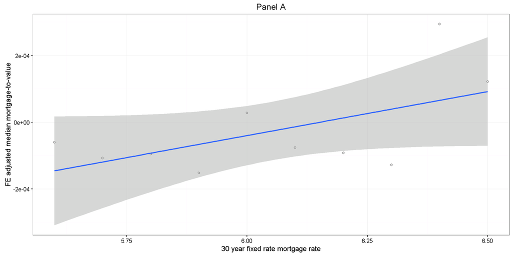

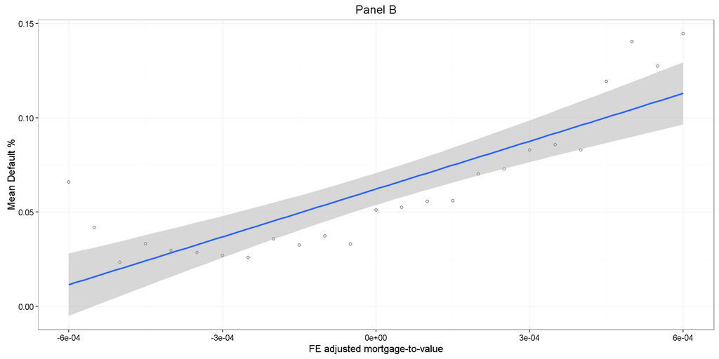

Back to top

## 2.5 Negative Equity: IV Regressions (Split by rent-to-value)

- Less than median: Loans from zip codes where median rent-to-value is less than the median(rent-to-value) in the same quarter
- Greater than median: Loans from zip codes where median rent-to-value is greater than the median(rent-to-value) in the same quarter

```
##
## =======================================================================================================================================================================================
##                                                                                              Y: def ; iv: mtg30us
##                         ---------------------------------------------------------------------------------------------------------------------------------------------------------------
##
##                         10% NE (rv<med) 10% NE (rv>med) 20% NE (rv<med) 20% NE (rv>med) 30% NE (rv<med) 30% NE (rv>med) 40% NE (rv<med) 40% NE (rv>med) 50% NE (rv<med) 50% NE (rv>med)
##                               (1)             (2)             (3)             (4)             (5)             (6)             (7)             (8)             (9)            (10)
## ---------------------------------------------------------------------------------------------------------------------------------------------------------------------------------------
## fico                      -0.0002***      -0.0002***      -0.0002***      -0.0002***      -0.0001***      -0.0002***      -0.0002***      -0.0002***       -0.00004       -0.0003***
##                            (0.00003)       (0.00003)       (0.00004)       (0.00005)       (0.0001)        (0.00004)       (0.0001)        (0.0001)        (0.0001)        (0.0001)
## ltv                          0.001          0.001**        0.003***          0.001          0.003**         0.002**        0.007***        0.003***        0.010***          0.003
##                             (0.001)         (0.001)         (0.001)         (0.001)         (0.001)         (0.001)         (0.001)         (0.001)         (0.002)         (0.002)
## dti                        0.0003**        0.0004***       0.001***        0.0004**        0.0005**        0.0004**        0.0005***        0.0002         0.0004**         0.001**
##                            (0.0001)        (0.0001)        (0.0001)        (0.0002)        (0.0002)        (0.0002)        (0.0002)        (0.0002)        (0.0002)        (0.0003)
## log(upb)                   0.833***         0.512**        1.219***        0.987***         0.596*         1.477***        1.263***          0.758         1.053***        1.555***
##                             (0.225)         (0.255)         (0.333)         (0.286)         (0.360)         (0.369)         (0.338)         (0.476)         (0.358)         (0.513)
## log(current_housevalue)    -0.832***       -0.508**        -1.203***       -0.988***        -0.588         -1.482***       -1.259***        -0.752         -1.034***       -1.548***
##                             (0.225)         (0.255)         (0.331)         (0.285)         (0.361)         (0.367)         (0.342)         (0.477)         (0.360)         (0.514)
## `mpay_value(fit)`          38.553**         29.668*        49.754**         19.201          65.775*         11.471         61.059**         36.309         89.518***        18.366
##                            (16.061)        (17.268)        (21.781)        (26.632)        (35.225)        (22.689)        (26.686)        (30.378)        (23.273)        (30.951)
## ---------------------------------------------------------------------------------------------------------------------------------------------------------------------------------------
## Observations                19,178          23,428          16,303          14,831          12,588           8,571           9,473           5,184           5,413           3,312
## Adjusted R2                  0.178           0.179           0.217           0.175           0.167           0.188           0.295           0.279           0.399           0.334
## =======================================================================================================================================================================================
## Note:                                                                                                                                                       *p<0.1; **p<0.05; ***p<0.01
##                                                                                                                                            Fixed Effects: zip * org year, zip * ne year
##                                                                                                                                             Standard Errors clustered by zip * org year
```

Back to top

## 2.6 Negative Equity: IV Regressions (Split by mortgage-to-rent)

- Less than median: Loans from zip codes where median mortgage-to-rent is less than the median(mortgage-to-rent) in the same quarter
- Greater than median: Loans from zip codes where median mortgage-to-rent is greater than the median(mortgage-to-rent) in the same quarter

```
##
## =======================================================================================================================
##                                                               Dependent variable:
##                         -----------------------------------------------------------------------------------------------
##                                              fico + ltv + dti + log(upb) + log(current_housevalue)
##                         10% NE (rv<med) 10% NE (rv>med) 20% NE (rv<med) 20% NE (rv>med) 30% NE (rv<med) 30% NE (rv>med)
##                               (1)             (2)             (3)             (4)             (5)             (6)
## -----------------------------------------------------------------------------------------------------------------------
## fico                      -0.0002***      -0.0002***      -0.0002***      -0.0001***      -0.0003***       -0.00005
##                            (0.00003)       (0.00003)       (0.00004)       (0.00005)       (0.0001)        (0.0001)
## ltv                         0.001**          0.001          0.002*          0.003**          0.003         0.010***
##                             (0.001)         (0.001)         (0.001)         (0.001)         (0.002)         (0.002)
## dti                        0.0004***       0.0003**        0.0005**        0.0004**         0.001**        0.0003**
##                            (0.0001)        (0.0001)        (0.0002)        (0.0002)        (0.0002)        (0.0002)
## log(upb)                    0.519**        0.821***        1.556***         0.590*         1.477***        1.086***
##                             (0.254)         (0.225)         (0.406)         (0.343)         (0.506)         (0.371)
## log(current_housevalue)    -0.516**        -0.820***       -1.561***        -0.582*        -1.469***       -1.067***
##                             (0.255)         (0.225)         (0.404)         (0.345)         (0.506)         (0.373)
## `mpay_value(fit)`           29.579*        38.641**         21.504          58.624*         22.293         88.552***
##                            (17.229)        (16.080)        (24.796)        (34.595)        (29.497)        (23.186)
## -----------------------------------------------------------------------------------------------------------------------
## Observations                23,574          19,032           8,267          12,892           3,499           5,226
## Adjusted R2                  0.179           0.178           0.203           0.162           0.340           0.398
## =======================================================================================================================
## Note:                                                                                       *p<0.1; **p<0.05; ***p<0.01
##                                                                            Fixed Effects: zip * org year, zip * ne year
##                                                                             Standard Errors clustered by zip * org year
```

Back to top

# 3 Positive Equity: Default ~ Mortgage-to-value + rent-to-value

- Sample: Loan enters in to the sample after borrower reaching the particular positive equity threshold and the default indicates whether borrower defaulted in the following 12 months after reaching the negative equity threshold.
- mtg30us: 30-Year Fixed Rate Mortgage Average in the United States in the loan origination month
- interest_diff: interest rate - mtg30us
- rent-to-value : median rent/median value for the zip code in the negative equity quarter

## 3.1 Positive Equity: IV Regressions

```
##
## =============================================================================
##                                         Y: def ; iv: mtg30us
##                         -----------------------------------------------------
##
##                           10% PE     30% PE     50% PE     70% PE    90% PE
##                            (1)        (2)        (3)        (4)        (5)
## -----------------------------------------------------------------------------
## fico                    -0.0001*** -0.0002*** -0.0002*** -0.0002*** -0.00003
##                         (0.00002)  (0.00003)  (0.00003)  (0.00003)  (0.00004)
## ltv                      0.001***    0.001*     0.001     -0.001*    -0.002
##                          (0.0003)   (0.001)    (0.001)    (0.001)    (0.002)
## dti                     0.0002***   0.0002*    0.00001    0.0002**  -0.00000
##                          (0.0001)   (0.0001)   (0.0001)   (0.0001)  (0.0001)
## log(upb)                 0.459***    0.022     -0.116*     -0.032    -0.038
##                          (0.103)    (0.069)    (0.063)    (0.075)    (0.037)
## log(current_housevalue) -0.457***    -0.029     0.118*     0.029      0.042
##                          (0.103)    (0.070)    (0.064)    (0.076)    (0.039)
## `mpay_value(fit)`       36.742***    -9.919     15.950     20.875    44.373
##                          (9.689)    (13.537)   (13.032)   (18.020)  (38.151)
## -----------------------------------------------------------------------------
## Observations              28,235     21,138     19,937     11,666     2,218
## Adjusted R2               0.176      0.169      0.122      0.152      0.441
## =============================================================================
## Note:                                             *p<0.1; **p<0.05; ***p<0.01
##                                  Fixed Effects: zip * org year, zip * ne year
##                                   Standard Errors clustered by zip * org year
```

Back to top

### 3.1.1 Alternative Default Definition: Default within 5 months

```
##
## =============================================================================
##                                         Y: def ; iv: mtg30us
##                         -----------------------------------------------------
##
##                           10% PE     30% PE     50% PE     70% PE    90% PE
##                            (1)        (2)        (3)        (4)        (5)
## -----------------------------------------------------------------------------
## fico                    -0.0001*** -0.0001*** -0.0001*** -0.0001*** -0.00000
##                         (0.00002)  (0.00002)  (0.00002)  (0.00002)  (0.00001)
## ltv                      0.0004**    0.0004    0.001**    -0.0001    -0.001
##                          (0.0002)   (0.0004)   (0.0004)   (0.0004)   (0.001)
## dti                     0.0001***   0.00003    0.00000    0.0001**  -0.00001
##                         (0.00004)   (0.0001)  (0.00005)   (0.0001)  (0.00004)
## log(upb)                 0.085**     0.054      -0.060     -0.043    -0.013
##                          (0.038)    (0.054)    (0.044)    (0.059)    (0.014)
## log(current_housevalue)  -0.087**    -0.059     0.060      0.040      0.014
##                          (0.039)    (0.055)    (0.045)    (0.060)    (0.015)
## `mpay_value(fit)`         8.780     -15.073     3.362      10.680    24.709
##                          (5.516)    (11.294)   (8.818)    (13.885)  (25.606)
## -----------------------------------------------------------------------------
## Observations              28,235     21,138     19,937     11,666     2,218
## Adjusted R2               0.022      0.028      0.042      0.111      0.317
## =============================================================================
## Note:                                             *p<0.1; **p<0.05; ***p<0.01
##                                  Fixed Effects: zip * org year, zip * ne year
##                                   Standard Errors clustered by zip * org year
```

Back to top

# 4 Control Variables

```
##
## =====================================================================================================
##                                                   Dependent variable:
##                   -----------------------------------------------------------------------------------
##                                         paste(variable, formula_text, sep = "")
##                       ltv            upb          fico         dti     currenthousevalue interestdiff
##                       (1)            (2)           (3)         (4)            (5)            (6)
## -----------------------------------------------------------------------------------------------------
## `mpay_value(fit)` 2,731.917*** -1,029,822.000   7,613.887  2,025.682**   3,235,754.000   -163.006***
##                    (928.245)   (6,796,577.000) (4,877.088)  (845.189)   (4,763,598.000)    (28.351)
## -----------------------------------------------------------------------------------------------------
## Observations         21,159        21,159        21,159      21,159         21,159          21,159
## Adjusted R2          0.813          0.125         0.023       0.009          0.120          -0.200
## =====================================================================================================
## Note:                                                                     *p<0.1; **p<0.05; ***p<0.01
##                                                          Fixed Effects: zip * org year, zip * ne year
##                                                           Standard Errors clustered by zip * org year
```

# 5 Rent Regression

```
##
## =====================================================================================================
##                                                    Dependent variable:
##                     ---------------------------------------------------------------------------------
##                                                       formula_list
##                                 (1)                        (2)                        (3)
## -----------------------------------------------------------------------------------------------------
## log(hpi)                     1.254***                   1.372***                   0.340***
##                               (0.023)                    (0.025)                    (0.020)
## Constant                     0.726***                    0.260*                    6.096***
##                               (0.120)                    (0.140)                    (0.111)
## -----------------------------------------------------------------------------------------------------
## year                            No                         No                         No
## zip                             No                         No                         No
## -----------------------------------------------------------------------------------------------------
## Observations                   4,157                      4,157                      4,157
## R2                             0.418                      0.438                      0.972
## Adjusted R2                    0.418                      0.437                      0.970
## Residual Std. Error      0.311 (df = 4155)          0.305 (df = 4149)          0.071 (df = 3923)
## F Statistic         2,982.021*** (df = 1; 4155) 461.866*** (df = 7; 4149) 577.437*** (df = 233; 3923)
## =====================================================================================================
## Note:                                                                     *p<0.1; **p<0.05; ***p<0.01
```

# 6 More splits (30% Negative Equity)

## 6.1 by rent-to-value quartiles

```
##
## ================================================================================
##                                           Dependent variable:
##                         --------------------------------------------------------
##                          fico + ltv + dti + log(upb) + log(current_housevalue)
##                             rv< Q1        rv< Q2        rv< Q3        rv> Q4
##                              (1)            (2)           (3)           (4)
## --------------------------------------------------------------------------------
## fico                       -0.00004      -0.0002**    -0.0002***     -0.0002**
##                           (0.00004)      (0.0001)      (0.00004)     (0.0001)
## ltv                         0.001        0.005***       0.002*         0.001
##                            (0.002)        (0.002)       (0.001)       (0.001)
## dti                         0.0002        0.001**      0.001***       0.0001
##                            (0.0001)      (0.0003)      (0.0003)      (0.0002)
## log(upb)                    0.089         0.980**      1.331***      1.910***
##                            (0.509)        (0.447)       (0.497)       (0.628)
## log(current_housevalue)     -0.073       -0.977**      -1.338***     -1.913***
##                            (0.506)        (0.452)       (0.494)       (0.624)
## `mpay_value(fit)`           58.127        71.815        -18.551       69.197*
##                            (45.301)      (44.709)      (29.411)      (40.730)
## --------------------------------------------------------------------------------
## Observations                5,420          8,139         4,830         2,770
## Adjusted R2                 0.177          0.166         0.171         0.247
## ================================================================================
## Note:                                                *p<0.1; **p<0.05; ***p<0.01
##                                     Fixed Effects: zip * org year, zip * ne year
##                                      Standard Errors clustered by zip * org year
```

## 6.2 by origination year

```
##
## ================================================================================
##                                           Dependent variable:
##                         --------------------------------------------------------
##                          fico + ltv + dti + log(upb) + log(current_housevalue)
##                              2005           2006          2007          2008
##                              (1)            (2)            (3)          (4)
## --------------------------------------------------------------------------------
## fico                       -0.0001        -0.00003      -0.0003**     -0.0002*
##                            (0.0001)       (0.0001)      (0.0001)      (0.0001)
## ltv                         0.003         0.016***      0.010***      0.005**
##                            (0.002)        (0.003)        (0.004)      (0.002)
## dti                        -0.00003        0.0004        0.001**      0.001**
##                            (0.0003)       (0.0004)      (0.0004)      (0.0004)
## log(upb)                    -0.626        -1.044*        1.360**      3.067***
##                            (0.708)        (0.541)        (0.646)      (0.515)
## log(current_housevalue)     0.663          1.067*       -1.374**     -3.092***
##                            (0.716)        (0.555)        (0.655)      (0.514)
## `mpay_value(fit)`         222.599***     131.622***      -52.308      -25.045
##                            (60.835)       (43.664)      (71.905)      (50.528)
## --------------------------------------------------------------------------------
## Observations                2,477          3,967          3,526        2,290
## Adjusted R2                 0.240          0.139          0.150        0.269
## ================================================================================
## Note:                                                *p<0.1; **p<0.05; ***p<0.01
##                                     Fixed Effects: zip * org year, zip * ne year
##                                      Standard Errors clustered by zip * org year
```

## 6.3 by house value

```
##
## ==============================================================================
##                                          Dependent variable:
##                         ------------------------------------------------------
##                         fico + ltv + dti + log(upb) + log(current_housevalue)
##                               Low House Value            High House Value
##                                     (1)                        (2)
## ------------------------------------------------------------------------------
## fico                              -0.0001                   -0.0002**
##                                  (0.0001)                    (0.0001)
## ltv                              0.003***                    0.003**
##                                   (0.001)                    (0.002)
## dti                               0.0005                      0.0004
##                                  (0.0003)                    (0.0002)
## log(upb)                           0.632                      0.526
##                                   (0.408)                    (0.431)
## log(current_housevalue)           -0.607                      -0.528
##                                   (0.412)                    (0.434)
## `mpay_value(fit)`                 82.390*                     50.790
##                                  (49.168)                    (40.431)
## ------------------------------------------------------------------------------
## Observations                       6,303                      6,285
## Adjusted R2                        0.165                      0.171
## ==============================================================================
## Note:                                              *p<0.1; **p<0.05; ***p<0.01
##                                   Fixed Effects: zip * org year, zip * ne year
##                                    Standard Errors clustered by zip * org year
```